# Final project Data Analysis Report

# 4 Descriptive analysis

## 4.1 Preprocessing and data cleaning

Firstly, this project load the data with former 5 sessions to the R for further study and analysis.

There are over 5 variables existing in the sessions, and for the research purposes, the variable “spks”(numbers of spikes of neurons in the visual cortex in time bins defined in specialized time), “contrast_left”(contrast of the left stimulus), “contrast_right”(contrast of the right stimulus) and “feedback_type”(type of the feedback, 1 for success and -1 for failure) are selected. And by checking the missing values, we can see that there are no missing values in this dataset.

## 4.2 Choice of the summary measure

For better understanding of the experiment, we should transform the “spks” variable to firing rate. And doing that could eventually generate 1196 firing rates across different sessions along with the time. Choosing such statistics for advanced analysis for mainly 4 reasons:

1. The first one would be the experimental design in the original paper. In the original paper, the analysis window is recorded from 0 to 0.4 s after stimulus onset, which means only the spikes of firing in this segment are recorded.
2. Selecting one indicator, which can express information of the relatively complicated data is more efficient and that would not lose too much information of the original data.
3. The mean help people understand the distribution of the data and the overall performance of the dataset.
4. The mean value can be used for further analysis, such as calculating the variance and standard deviation.

## 4.3 Univariate descriptive analysis

Before further analysis of our research interests, the explanatory data analysis is needed for getting fundamental understanding of the structure, characteristics and properties of dataset. And such analysis could show the readers the pattern in the data and correlation between variables, which would eventually provide how the explaining variables affect the response variables and help to guide the modeling and further analysis.

Firstly, to show the detailed information of the amounts and mean firing rates of various contrasts level, the tables are offered below:

**Table1 Summary contrasts of Mouse Cori**

| Contrast.level | session 1 Left1 | session 1 Right1 | session 2 Left2 | session 2 Right2 | session 3 Left3 | session 3 Right3 |
| --- | --- | --- | --- | --- | --- | --- |
| 0.00 | 97 | 86 | 133 | 115 | 137 | 109 |
| 0.25 | 46 | 25 | 25 | 41 | 31 | 26 |
| 0.50 | 36 | 41 | 39 | 34 | 28 | 31 |
| 1.00 | 35 | 62 | 54 | 61 | 32 | 62 |

**Table2 Summary contrasts of Mouse Frossman**

| Contrast.level | session 4 Left4 | session 4 Right4 | session 5 Left5 | session 5 Right5 |
| --- | --- | --- | --- | --- |
| 0.00 | 112 | 107 | 112 | 105 |
| 0.25 | 41 | 55 | 46 | 48 |
| 0.50 | 46 | 41 | 43 | 45 |
| 1.00 | 50 | 46 | 53 | 56 |

Based on the table result above, we can see that the left and right stimuli amounts across different sessions. And based on the the original paper of Steinmetz et al. (2019), we can know the amounts of the left and right stimuli are set randomly. And for each session, even if there are different amounts of left contrasts and right contrasts, the total contrasts from different levels and type(left and right) holds.

**Table3 Summary Feedback types and mean firing rate of Mouse Cori**

| Variable | session 1 Success1 | session 1 Failure1 | session 2 Success2 | session 2 Failure2 | session 3 Success3 | session 3 Failure3 |
| --- | --- | --- | --- | --- | --- | --- |
| amount | 141.00 | 73.00 | 159.00 | 92.00 | 151.00 | 77.00 |
| mean firing rate | 4.34 | 3.75 | 3.39 | 3.21 | 3.72 | 3.33 |

**Table4 Summary Feedback types and mean firing rate of Mouse Frossman**

| Vairable | session 4 Success4 | session 4 Failure4 | session 5 Success5 | session 5 Failure5 |
| --- | --- | --- | --- | --- |
| amount | 166.00 | 83.00 | 168.00 | 86.00 |
| mean firing rate | 2.14 | 2.06 | 1.49 | 1.18 |

## 4.4 Multivariate descriptive analysis

To get more clear description of the dataset, a Jitter-plot is drawn for better explanation as shown below:

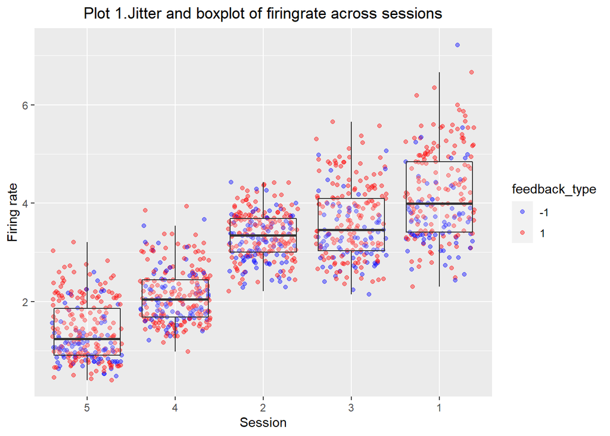

Based on the jitter-boxplot shown above, we can see that the session1 have an obvious higher firing rate as well as the most dispersed distribution. And for the mouse Cori, the data is more distributed than the mouse Frossman. Moreover, the mouse Cori have higher firing rate even in different sessions.

Moreover, we can see that the failure feedback type has generally lower firing rate than the success feedback type across different sessions. Therefore, it is reasonable to guess that for failure feedback, the neuron activity would act less compare with the success feedback type. In other words, whenever the mouse get succeed in reacting correctly, they would normally have more neuron activities. However, for the session1, which is the session has higher firing rate, the success and failure feedback would have a more even distribution than what the other sessions.

Based on the analysis above, it is reasonable to guess that the firing rate would differ a lot for different sessions, hence in the subsequent quantitative analysis, it is necessary to set then as random intercept in our model to reduce the influences.

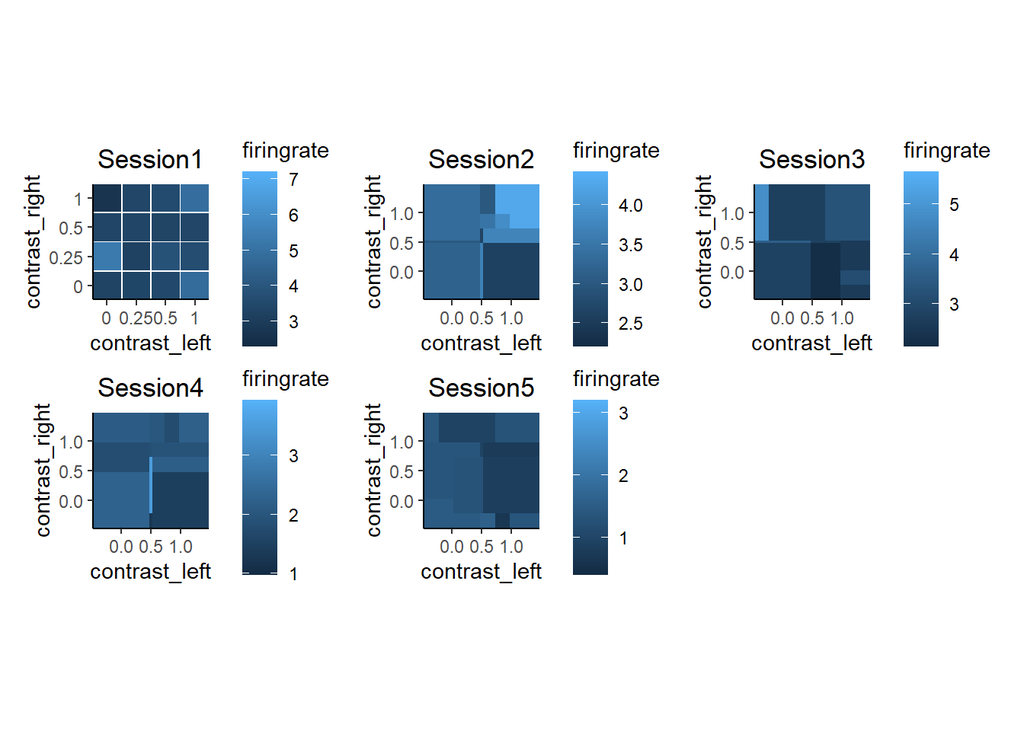

# 5 Inferential analysis

## 5.1 Overview and parameters explanation

Based on the research interests, an ANOVA model as follows: $Y_{ijkl} = \mu_{...} + \alpha_{i} + \beta_{j} + \gamma_{k} + (\alpha \beta)_{ij} + \epsilon_{ijkl}$ is used for Inferential analysis. In this model, the index $i$ represents the fixed effects: left contrasts: 0 ($i=1$), 0.25 ($i=2$), 0.5 ($i=3$), 1 ($i=4$), and the index $j$ represents the fixed effects: right contrasts: 0 ($j=1$), 0.25 ($j=2$), 0.5 ($j=3$), 1 ($j=4$), $k$ represents the session indicator, which is treated as the random effect in this case since the research interests mainly focus on how the stimuli affect the neuron level and switching the session does affect the model structure, $l$ represents the neuron indicator, $\epsilon_{ijkl}$ represents the unobserved error and $\mu_{...}$ represents the population mean firing rate in this case.

## 5.2 Model choosing

However, in this project, we consider the random effect into the model, here we use the LR test and F test to test if the random effect is significant enough in our model. And based on the R result, we can get the p-value for the result without random effect is shown below:

**Anova Table of final model**

| X. | Df | Sum.Sq | Mean.Sum.Sq | F.value | Pr..F. |
| --- | --- | --- | --- | --- | --- |
| contrast_right | 3 | 3.1 | 1.022 | 0.747 | 5.24e-01 |
| contrast_left | 3 | 54.2 | 18.083 | 13.209 | 0.00e+00 |
| Interaction | 9 | 62.0 | 6.884 | 5.029 | 1.10e-06 |
| Residuals | 1180 | 1615.4 | 1.369 | NA | NA |

However, to consider whether there is an interaction term existed in the model, the interactions still need to be verified in a statistical way to see how the combination of them would attach effect on the firing rate. Hence the reduced model is established in this case to verify if the reduced model has a better efficiency of analysis and dropping such terms would attach negative influence on the model accuracy. In this project, Based on the R result, we can see that under the confidence level 0.05, the p-value for comparing the two models is way less than 0.05. Hence, we can say that the more complicated model is better than the reduced model, and this interaction term should continue to stay in this model and not to get removed.

Therefore, we should keep the oringial complicated model for further analysis.

## 5.3 assumptions on proposed model

Based on the explanation of each parameters, we can get the constraints on the $\alpha_i$ and $\beta_j$ as $\sum_{i=1}^a \alpha_i = \sum_{j=1}^b \beta_j=0$ and $\epsilon_{ijk}$ are i.i.d. $N(0,\sigma^2)$.

The assumptions on this model would mainly focus on that $\epsilon_{ijkl}$ are i.i.d. $N(0,\sigma^2)$. Here we can list them out for better understandings:

1. According to the formula above, equal variance of response variables for different factor levels can be represented by error terms having the same variance.
2. The independence of data can be represented in the formula by error terms being independently distributed, meaning they are not affected by or related to each other.
3. For the formula above, the assumption of identical normal distribution of response variables for different factor levels can be represented by error terms having an identical normal distribution with an expected value of 0.

## 5.4 Model fitting

**Anova Table of final model**

| X. | npar | Sum.Sq | Mean.Sum.Sq | F.value |
| --- | --- | --- | --- | --- |
| contrast_right | 3 | 14.4620 | 4.8207 | 12.0656 |
| contrast_left | 3 | 25.3466 | 8.4489 | 21.1465 |
| Interaction | 9 | 6.9621 | 0.7736 | 1.9361 |

## 5.5 hypotheses test and inference

Based on the research purpose, firstly we can set up the hypotheses test for the contrast_right.

$H_0: \alpha_{i}=0 \space\space \forall\space\space i \space\space\space\space v.s.H_1: not \space all\space \alpha_i\space are\space zero$

Then we can set up the hypotheses test for different contrast_left.

$H_0: \beta_{j}=0 \space\space \forall\space\space j \space\space\space\space v.s.H_1: not \space all\space \beta_j\space are\space zero$

However, even if knowing the variables does attach influence on the response variables, the ANOVA model still is less capable of telling which one of combinations of contrast level would affect more. Therefore, the further analysis is needed.

## 5.6 Classfication

Based on the explanatory data analysis, we can know that for each combination of left and right contrasts of various levels and various firing rate, they would represent different neurons level. Although it may be the same neurons of the mouse act differently across sessions, we can consider them as different neurons to investigate how their firing rates are affected by different combination of contrast levels and types.

In this project, the method of classification would mainly use the K-means method to fulfil the classification based on its high-efficiency and interpretable. Moreover, the k-means clustering algorithm is easy to implement, and has good performance when processing large datasets.

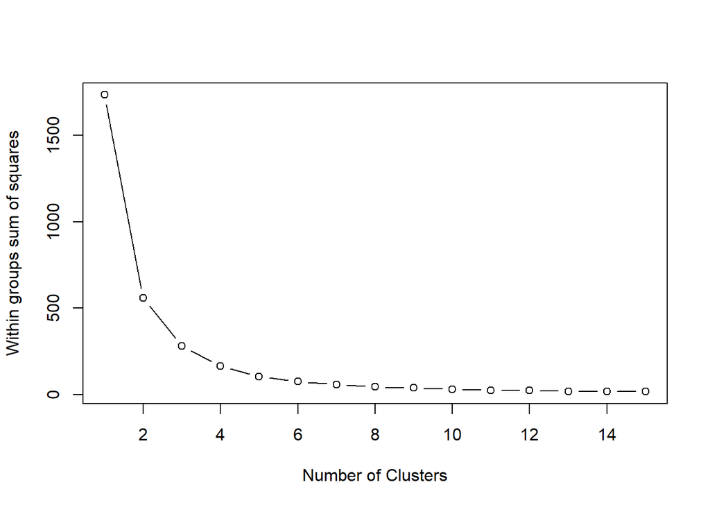

Based on the plot shown above, here we use the Total within sum of squares as the criterion. By showing the goodness of different cluster choosing, we can see the overall goodness would increase with the increasing number of clusters, but the growth trend does not grow very quickly after CLUSTER reaches three. Considering efficiency and explanatoryness, the KMEANS method of choosing 3 clusters is used to classify the data.

Based on the determined number of clusters, the project can draw the plot to show how the combination of left and right contrasts attach influence on the mean firing rate. Based on the clustering results, the project shows that for the first cluster, the mean firing rate is shown below:

**Table6 Summary Means of each cluster**

| Index | Cluster.1 | Cluster.2 | Cluster.3 |
| --- | --- | --- | --- |
| Mean | 1.51744 | 4.519926 | 3.129715 |

Moreover, we can plot the bar chart to show the counts of each combination of contrasts in each cluster. Here we use the number indicator to represent the combination of contrast: 1 stands for the left-contrast of 0 with the right-contrast of 0, 2 stands for the left-contrast of 0 with the right-contrast of 0.25, 3 stands for the left-contrast of 0 with the right-contrast of 0.5, 4 stands for the left-contrast of 0 with the right-contrast of 1. 5 stands for the left-contrast of 0.25 with the right-contrast of 0, 6 stands for the left-contrast of 0.25 with the right-contrast of 0.25, 7 stands for the left-contrast of 0.25 with the right-contrast of 0.5, 8 stands for the left-contrast of 0.25 with the right-contrast of 1. 9 stands for the left-contrast of 0.5 with the right-contrast of 0, 10 stands for the left-contrast of 0.5 with the right-contrast of 0.25, 11 stands for the left-contrast of 0.5 with the right-contrast of 0.5, 12 stands for the left-contrast of 0.5 with the right-contrast of 1. 13 stands for the left-contrast of 1 with the right-contrast of 0, 14 stands for the left-contrast of 1 with the right-contrast of 0.25, 15 stands for the left-contrast of 1 with the right-contrast of 0.5, 16 stands for the left-contrast of 1 with the right-contrast of 1.

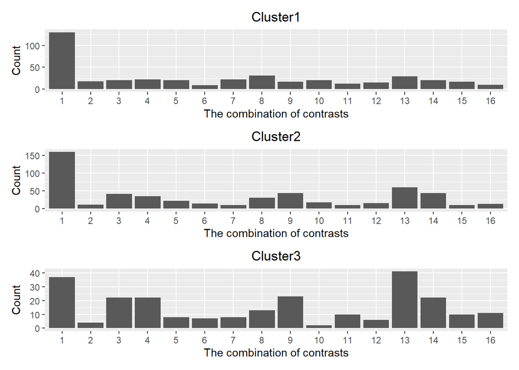

# 6 Sensitivity analysis

## 6.1 Assumptions test based on plots

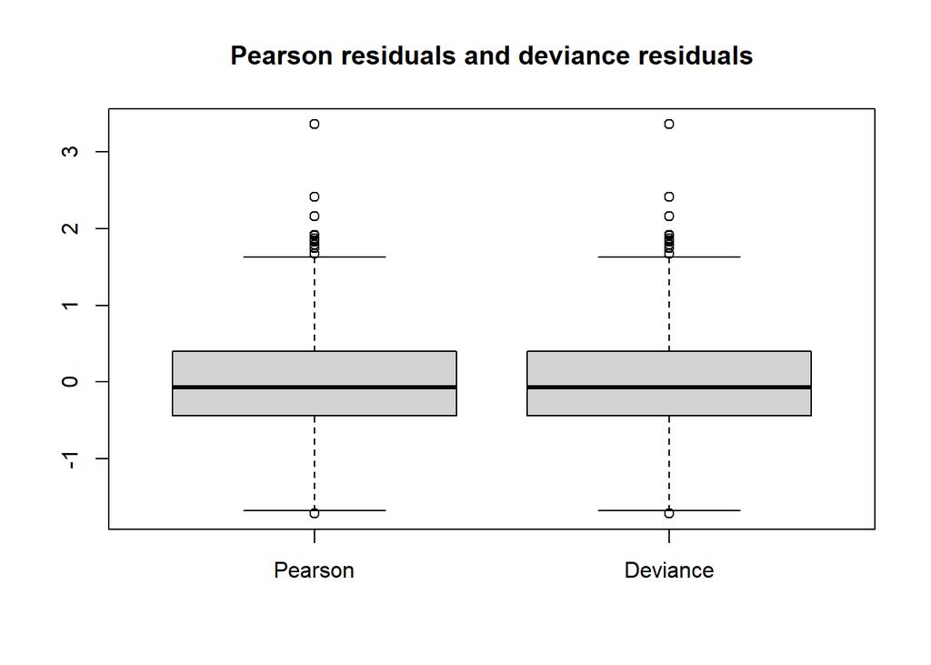

From the Pearson residuals and deviance residuals, we can see that the two kinds of residuals are quite similar to each other, the model would not suffer from potential lack-of-fit.

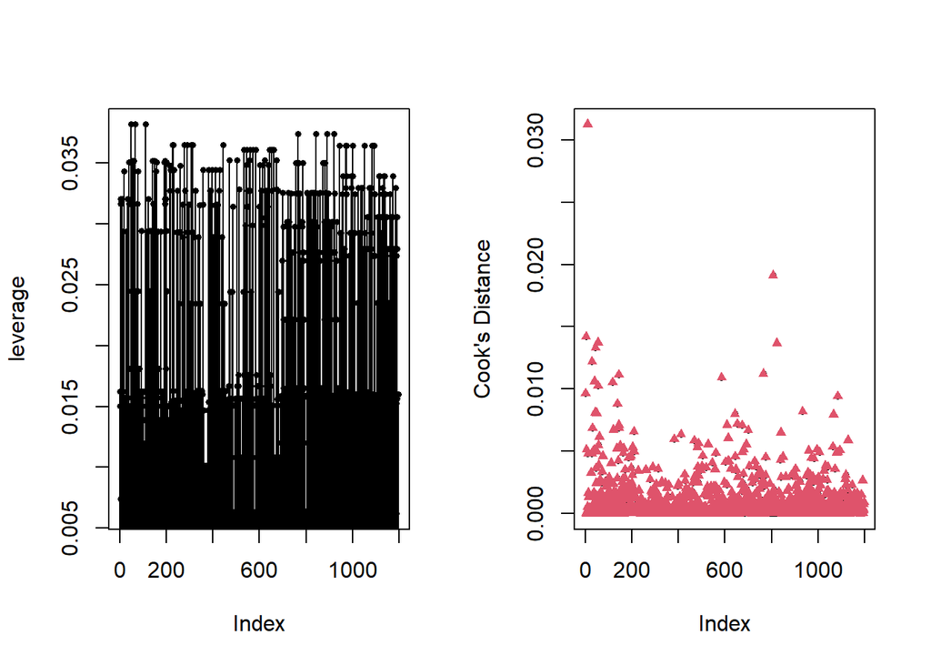

For outliers test, this project use the cooks distance and leverage plot to determine. However, in this project, the outliers are too less and not obvious enough that will have a significant impact on normality and variance homogeneity. It may be beneficial to remove potential outliers, but in this case, the project consider not to remove them for better effiency and interpretation.

## 6.2 Assumptions test based on quantiles

Based on the Shapiro-Wilk normality test result, we can get that the test result shows the evidence of normality violation. And we can get that the Our sample does not come from a normally distributed population. However, in this project the transformation of the data or other ways are not considered to be used for better interpretation and efficiency. Moreover, since we have large sample in this project, which by Central limit theorem, the original distribution of the data would attach negative influence on the analysis.

Based on the R result, we can see that the p-values from Levene’s tests is higher than the significance level of 0.05. This indicates that there is evidence of significantly equal variances of error terms. As a result, we can infer that the variations in the different contrast levels and sessions are homogeneous.

## 6.3 Alternative methods

To verify our conclusion, another methods are necessary to see if the results are different from the conclusion gained. Here we take two of variable as random effect, which is the mouse and session number. Since taking the mouse as random effect can help us to remove the individual differences across various experimental object. Moreover, if the conclusion still holds, the conclusion drawn would be more reliable.

**Anova Table of alternative model**

| X. | Df | Sum.Sq | Mean.Sum.Sq | F.value |
| --- | --- | --- | --- | --- |
| contrast_right | 3 | 14.4798 | 4.8266 | 12.0804 |
| contrast_left | 3 | 25.3314 | 8.4438 | 21.1338 |
| Interaction | 9 | 6.9568 | 0.7730 | 1.9347 |

Based on the R result above, we can see that all variables have the large F-value, indicating all variables would have statistically significant impact on the response variable, the mean firing rate. And that would help to cross-validate our result and conclude that the left and right contrast would attach influence on the neuron activities.

# 7 Prediction

For the second research interest, this project apply the logistic regression, which take the feedback type as the response variable and the firing rates and contrast levels as the explanatory variables. And here this project uses the ROC curve as the measures of Goodness-of-fit of this logistic regression.

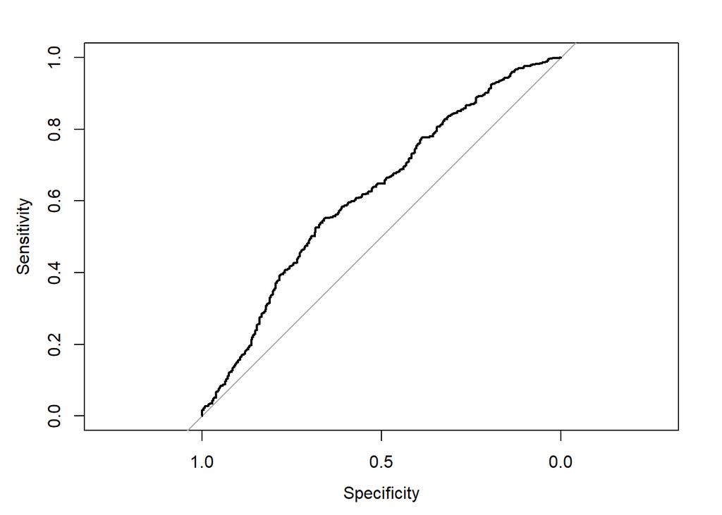

```
##        actual_values
## pvalues -1  1
##      -1  4  3
##      1  22 71
```

Based on the R result, we can get Sensitivity (True positive rate): the probability of a positive test result, conditioned on the individual truly being positive as below:
$$\frac{TP}{TP+FN}=71/74\approx0.96$$

And the Specificity (True negative rate): the probability of a negative test result, conditioned on the individual truly being negative as below:

$$\frac{TN}{TN+FP}=4/26\approx0.15$$

Based on the low Specificity, the prediction results can result in false positives, which means during the prediction, we may cause the mistake that gather the failure feedback into success feedback.

# 8 Discussion

## 8.1 Conclusion

After detailed analysis using ANOVA method and clustering methods as well as using the logistic regression as the prediction method, the report can generate the conclusion that there are significant differences in mean firing rate in different contrast levels and different session, which means different time and mouse, under the confidence level of 0.05, And the combination of contrast levels with high stimulation would generally have the relative higher mean firing rate compare to other situation. That means, with more stimuli, the neuron activity would be more active.

## 8.2 Analysis interpretation

At first, The report use the descriptive analysis to investigate whether there are differences between mean firing rate in different sessions. After that, the further analysis using two-way ANOVA method with random effect also proved that conclusion. Despite the violation of the basic assumption of ANOVA, the conclusion stil holds for the large sample size. Hence the conclusion can be correct taken for further analysis.

Generally, knowing the visual stimulation would attach influence on the neuron activity is very important in the the neuron areas, since such conclusion would help the researchers to set up subsequent and following research to investigate what happen to brains during the stimuli. Especially helpful for those who want to study the on the further analysis on human beings and related research.

## 8.3 Forward-looking and Caveats of the current analysis

By knowing the conclusion, the subsequent researchers can avoid complicated modelling and directly use the conclusion that the contrasts level would affect the neuron activities. Based on that, the related companies could set experiments aiming at helping to design new drugs and reduce the time of trails of new drugs. And it can also attach influence on understanding biological brains, which eventually help artificial intelligence to deal with the input such as visual stimuli. Overall, the conclusion of the project does help the related public reduce their work and become more inspired in such areas.

Despite the correctness of the conclusion, the method using in this report may need further analysis or fix to be more general. For example, using more data from different sessions. Moreover, the next editors or upcoming users of this report should keep in mind that the report does not use the transformation of the original data because the interpretation for that would be much more complicated and thus lead to misunderstanding of important explanations. And the clustering method can be improved to another level, such as using random forest or svm method to cross-validate the research. And the prediction can try more tools such as generalized linear model instead or using the decision tree to verify conclusion or get a more solid prediction result as well.

# Acknowledgement

“Yichu Chen”, “Shuang Wu”, “Dawei Wang”

# Reference

1.Steinmetz, N.A., Zatka-Haas, P., Carandini, M. et al. Distributed coding of choice, action and engagement across the mouse brain. Nature 576, 266–273 (2019).

2.Cisek, P. & Kalaska, J. F. Neural mechanisms forinteracting with a world full of action choices. Annu. Rev. Neurosci. 33, 269–298 (2010).

3. Jun, J. J. et al. Fully integrated silicon probes forhigh-density recording of neural activity. Nature 551, 232–236 (2017).
4. Allen W.E. et al. Thirst regulates motivated behaviorthrough modulation of brainwide neural population dynamics. Science. 364(6437):253 (2019) ***

# Session info